# Sleep Well

Junhee Park, Ji Min Sung, William Yuen, and Rohan Simha

Autumn 2022

#### INFO-201: Technical Foundations of Informatics - The Information School - University of Washington

**Code Name: REM**

```r
source("../source/chart_1.R")
source("../source/chart_2.R")
source("../source/chart_3.R")
```

```r
source("../source/Table.R")
```

## **Abstract**

> Our *main question* is **How to have the highest performance for the day with a good quality of sleep.** This question is important because approximately 70 million Americans suffer from Insomnia every year. To address the question, we will collect data on sleep and figure out what the main causes of sleep disorders are.

## **Key Words**

- Sleep Quality
- Stress Level
- Average Amount of Sleep
- Stress Level

## **Introduction**

> A lot of college students, workers, and high school seniors have been experiencing stressful days recently. One of the biggest causes that let people experience stressful days is they have a lack of sleep. There might be a lot of reasons why people do not sleep. It can be staying up to work on assignments for school, working late for their job, or preparing for college with anxiety. But one of the biggest reasons why people stay up late and have stressful days is that they do not know how to control their sleep schedule. The *Sleep Well* projects will help users to have a good amount of sleep with an organized sleep schedule that is built based on sleep data collected from Google Data Search.

## **Problem Domain**

> **Our project framing** is to analyze the three different sleep data to combine all together to create an average [sleep time schedule](https://healthysleep.med.harvard.edu/healthy/science/what/sleep-patterns-rem-nrem) which could be helpful to stakeholders. **For [human values](https://health.clevelandclinic.org/sleep-and-health/),** sleep enables us to [repair our body condition](https://newsinhealth.nih.gov/2013/04/benefits-slumber#:~:text=%E2%80%9CSleep%20affects%20almost%20every%20tissue,obesity%2C%20heart%20disease%20and%20infections) while we are sleeping and prepares us for the coming day. If we ruin our sleep cycle, it may affect our mental and physical health. **Our project direct stakeholder** might be anyone who uses our *“Sleep Well”* website which means it can be people who are experiencing insomnia, trouble with sleeping, or having a good sleep schedule. **The possible benefits** for direct stakeholders are that their health will be recovered because they will get enough sleep with good sleep schedules, and they could check whether they are having good sleep schedules or not. **The possible harm** for direct stakeholders is that this website could create pressure on the users to sleep and give anxiety when users have to stay up late for various reasons. **Our indirect stakeholder** might be the people who collected and provided the sleep data. **The possible benefits** for indirect stakeholders are that they could spread their valuable information and data to more people through our projects since we are using their data.**The possible harm** for indirect stakeholder is that If our project fails to provide proper information to direct stakeholder and rather adds to the confusion, the original data collectors can also have a negative impact from our project.
- hortonj4. (2021, October 26). How does sleep affect your health. Cleveland Clinic. Retrieved October 31, 2022, from https://health.clevelandclinic.org/sleep-and-health/
- Natural patterns of sleep. Natural Patterns of Sleep | Healthy Sleep. (n.d.). Retrieved October 31, 2022, from https://healthysleep.med.harvard.edu/healthy/science/what/sleep-patterns-rem-nrem
- U.S. Department of Health and Human Services. (2018, April 4). The benefits of slumber. National Institutes of Health. Retrieved October 31, 2022, from https://newsinhealth.nih.gov/2013/04/benefits-slumber#:~:text=%E2%80%9CSleep%20affects%20almost%20every%20tissue,obesity%2C%20heart%20disease%20and%20infections.

## **Research Questions**

- **What is causing people to have a lack of sleep?**
  - People should know the main causes of lack of sleep so they can control and rebalance their sleep cycle to make a better quality of life and sleep. This question is one of the main questions of our project. The quality of sleep is very important and it always affects our lives.
- **What is the average amount of sleep that lets people wake up feeling well rested?**
  - It is important to know the average amount of sleep that lets people wake up feeling well-rested because this data will individually provide the recommended amount of sleep time for users, based on their wake-up time for the last week and the data of average amount of sleep that lets people wake up feel well-rested ,in order to wake up feeling well-rested.
- **How does the amount of sleep affect stress levels?**
  - Usually people have a difficult time sleeping when they have a stressful day. At high levels of stress, falling asleep takes longer and sleep is fragmented. [Dr. Annise Willson](https://www.bcm.edu/news/how-stress-can-affect-your-sleep) explained, *“sleep loss triggers our bodies’ stress response system, resulting in an elevation of the stress hormone cortisol.”*

## **The Dataset**

| Name of data file | Number of observation(rows) | Number of variables(columns) |
| --- | --- | --- |
| sleepdata.csv | 887 | 8 |
| sleepdata_2.csv | 921 | 21 |
| SleepStudyData.csv | 104 | 6 |

### **Provenance of Dataset**

> Dana Diotte used the Sleep Cycle iOS app from Northcube to collect the data. Her first dataset (sleepdata.csv) was collected from 2014-2018. Her second dataset (sleepdata_2.csv) was uploaded in April 2022 and it was a continuation of her first dataset from 2018. She did not have any specific purpose for collecting the data other than that she wanted to see how her collection of data looked versus how others’ collections of data looked like. There is no insight to how the collection of this data was funded, but there was a research project that used that dataset. This project is titled “From 887 days of sleep data to personalized suggestion” and is by Xiao Yang, a PhD and senior Data Scientist and Research Lead at Mindstrong. We obtained these datasets by going to www.kaggle.com/datasets and searching “sleep data”. Xiao Yang, and any readers viewing this project will benefit from the dataset Dana Diotte’s dataset. This data is held secure by kaggle, and it is credible and trustworthy because all the data is collected from data on the source of this data, the Sleep Cycle iOS app, and all the entries are specific entries from users.

## **Expected Implications**

**Technologists:** They can develop and release the application or website to help people’s good sleep cycle. Through the application or website, they suggest the amount of sleep time to users so users can have good quality of sleep.

**Designers:** They can design applications or websites with a user-centered design by identifying direct and indirect stakeholders, researching, interviewing, and surveying people to make the app or websites more user-friendly.

**Policymakers:** It can be company or university policymakers. Basically, the main idea is the same which is putting the limitation of work time. So, people are not experiencing the overwhelming and guaranteed sleep time.

## Exploratory Analysis

#### Sourcing “Summary_Information.R” file

```r
source("../source/Summary_Information.R")
summary_info
```

```
## $num_observations
## [1] 887
##
## $Sleep_quality_max_value
##   Sleep.quality
## 1           99%
## 2           99%
## 3           99%
## 4           99%
## 5           99%
```

#### Dynamic Paragraph 1

We used the “sleep data” to calculate the maximum value of sleep quality to figure out the best quality of sleep in this data. All the values we calculated were the same which is “99%”. According to dataset, usually 99% sleep quality also have more than 8 hours 30 minutes sleep time. Based on our calculation, we assume that sleep quality is closely related to amount of sleep time.

```r
source("../source/Summary_Information.R")
summary_info_2
```

```
## $num_observations
## [1] 921
##
## $Steps_min_value
##    Steps
## 1      0
## 2      0
## 3      0
## 4      0
## 5      0
## 6      0
## 7      0
## 8      0
## 9      0
## 10     0
## 11     0
```

#### Dynamic Paragraph 2

We used the “sleepdata_2” to calculate the minimum value of steps in a day to figure out how the steps are related to the snore time. All the values we calculated were the 0 which is no steps. Based on dataset, when the steps data is 0, most of snore times were also 0. We could assume that people don’t snore when they have no steps in a day.

```r
source("../source/Summary_Information.R")
summary_info_3
```

```
## $num_observations
## [1] 630
##
## $stress_level_max_value
##     sl
## 1    4
## 2    4
## 3    4
## 4    4
## 5    4
## 6    4
## 7    4
## 8    4
## 9    4
## 10   4
```

[output cut: 116 more lines]

#### Dynamic Paragraph 3

We used the “SaYodata” to calculate the maximum value of stress level to see how the stress level is related to heart rate during the sleep time. All the values we calculated were the 4 which is the highest stress level In this dataset. According to dataset, when people have level 4 of stress level, their heart rate is also pretty high averagely. The average of heart rate when the stress level reached to 4 is 84%. Comparing to the heart rate when stress level is 0, it is dynamically high since the stress level 0 heart rate is 54% averagely.

```r
source("../source/Summary_Information.R")
summary_info_4
```

```
## $num_observations
## [1] 887
##
## $Heart_rate_max_value
##   Heart.rate
## 1         98
```

#### Dynamic Paragraph 4

We used the “sleep data” to calculate the maximum value of heart rate to figure out the cause of the high value of heart rate. The highest heart rate we calculated was 98 which is very not good for our health. We compared all the features we have and we found one common cause to have high heart rate. It was “drank coffee”. Based on dataset, there is one feature called, “Sleep notes”. When people drank coffee before sleep, we found the high heart rate during their sleep time. We strongly believed that drinking coffee is not good for sleep

```r
source("../source/Summary_Information.R")
summary_info_5
```

```
## $num_observations
## [1] 921
##
## $Regularity_min_value
##   Regularity
## 1        -1%
```

#### Dynamic Paragraph 5

We used the “sleepdata_2” to calculate the minimum value of regularity to figure out how the regularity affect to the sleep quality. When we calculated the minimum value of the regularity, we got -1 which is very low value. It showed us that data has very unstable sleep regularity. According to dataset, we could find the relationship between the regularity and sleep quality. When regularity has -1%, the sleep quality was 49%. The dataset clearly showed us that regularity is the one of the important element of the sleep quality.

## Charts

**Chart 1**

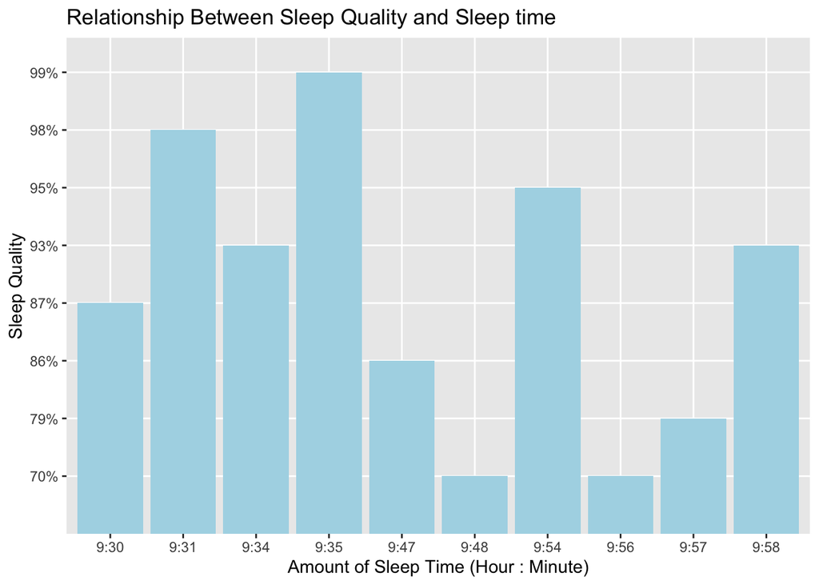

[figure not shown]

```r
plot(bar_2)
```

**Chart 2**

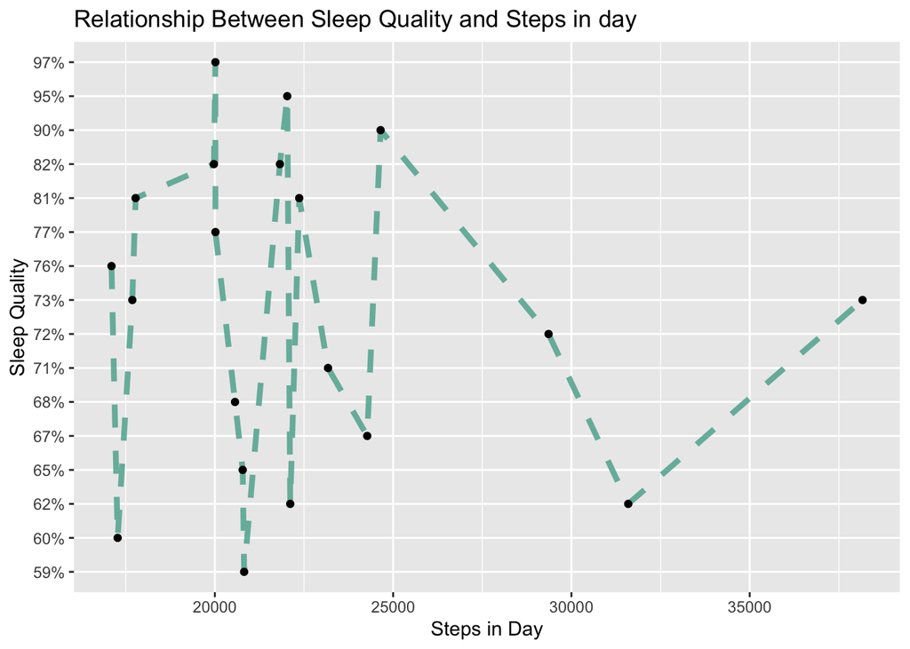

- *We included the chart to figure out the relationship between steps in a day and sleep quality. This chart shows around 20000 steps in a day has the best quality of sleep*

**Chart 3**

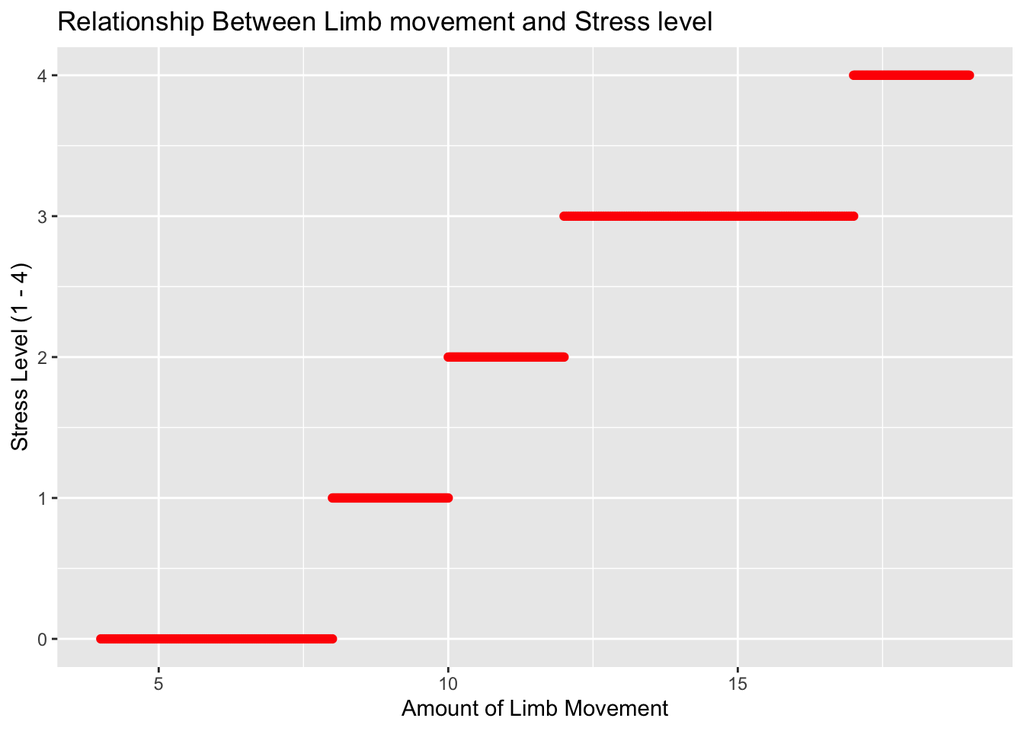

- *We included the chart to figure out the relationship between amount of limb movement and stress level. This chart clearly shows when stress level is increasing, the amount of limb movement is also increasing.*

### Stress Level and Average Sleeping Hour Table

| Stress Level | Average Sleeping Hour |
| --- | --- |
| 0 | 8.0 |
| 1 | 6.0 |
| 2 | 3.5 |
| 3 | 1.0 |
| 4 | 0.0 |

- *We added this **Table of Stress Levels and Average Sleeping Hours** to see how sleeping time can affect stress levels. This data table informs that as the sleeping hours decrease, the stress level will increase because in the table when a person has zero amount of sleep time will eventually cause them to have level 4 of Stress which is a maximum stress level. Similarly, in the table, when a person had 8 hours of sleep, his or her stress level would be 0. This data table will be useful for us to find what the average time of sleep is best to reduce the stress level.*

## **Acknowledgements**

> Thanks to the data provider, and TAs.

## **References**

- Diotte, D. (2022, April 25). *Sleep data.* Kaggle. Retrieved October 28, 2022, from https://www.kaggle.com/datasets/danagerous/sleep-data?select=sleepdata_2.csv
- *How stress can affect your sleep.* Baylor College of Medicine. (n.d.). Retrieved October 28, 2022, from https://www.bcm.edu/news/how-stress-can-affect-your-sleep
- Rachakonda, L. (2022, February 15). *Human stress detection in and through sleep.* Kaggle. Retrieved October 28, 2022, from https://www.kaggle.com/datasets/laavanya/human-stress-detection-in-and-through-sleep?select=SaYoPillow.csv
- Diotte, D. (2022, April 25). *Sleep data.* Kaggle. Retrieved October 28, 2022, from https://www.kaggle.com/datasets/danagerous/sleep-data?select=sleepdata.csv
- hortonj4. (2021, October 26). How does sleep affect your health. Cleveland Clinic. Retrieved October 31, 2022, from https://health.clevelandclinic.org/sleep-and-health/
- Natural patterns of sleep. Natural Patterns of Sleep | Healthy Sleep. (n.d.). Retrieved October 31, 2022, from https://healthysleep.med.harvard.edu/healthy/science/what/sleep-patterns-rem-nrem
- U.S. Department of Health and Human Services. (2018, April 4). The benefits of slumber. National Institutes of Health. Retrieved October 31, 2022, from https://newsinhealth.nih.gov/2013/04/benefits-slumber#:~:text=%E2%80%9CSleep%20affects%20almost%20every%20tissue,obesity%2C%20heart%20disease%20and%20infections.